# STAT UN2103 HW5

Rebekah Kim

November 29, 2016

## I. Introduction

### a. Goal of analysis

#### Research Questions

We would like to know the answer to the following research questions:

> 1. Do Blacks have statistically different wages compared to Whites?
> 2. Do Blacks have statistically different wages compared to all other races?

and build a model that takes relevant predictors for the response, wage.

### b. Setup

```r
df <- read.csv("salary.txt", header = T)

set.seed(0)
index <- sample(1:nrow(df),4965,replace = F)
train.data <- df[-index,]
data <- train.data
test.data <- df[index,]
```

### c. Exploratory Data Analysis with Interaction Plots

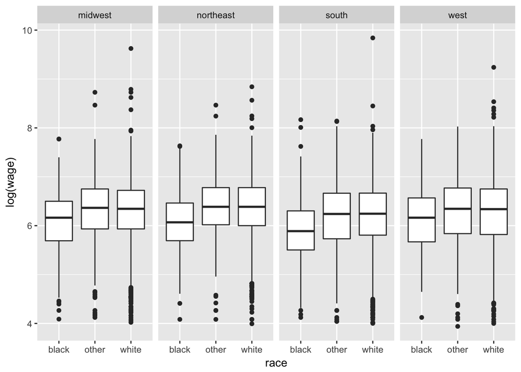

```r
# Race (race) by Region (reg)
ggplot(data, aes(x = race, y = log(wage)))+
  geom_boxplot() +
  facet_wrap(~reg, nrow = 1)
```

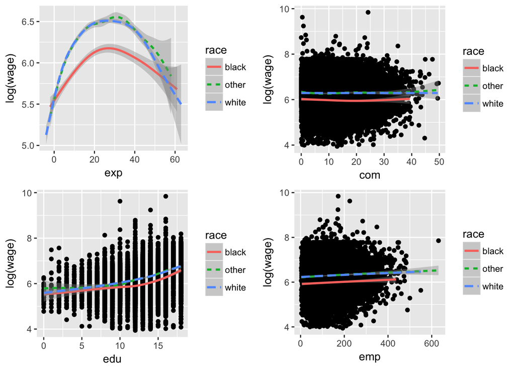

```r
# Experience (exp)- interaction with Race
plot1 <- ggplot(data, aes(x = exp, y = log(wage), group = race)) +
  geom_smooth(aes(linetype = race, color = race))

# Commute distance (com)
plot2 <- ggplot(data, aes(x = com, y = log(wage))) +
  geom_point() +
  geom_smooth(aes(linetype = race, color = race))

# Education years (edu)
plot3<- ggplot(data, aes(x = edu, y = log(wage))) +
  geom_point() +
  geom_smooth(aes(linetype = race, color = race))

# Number of Employees (emp)
plot4 <- ggplot(data, aes(x = emp, y = log(wage))) +
  geom_point()+
  geom_smooth(aes(group = race, linetype = race, color = race))

grid.arrange(plot1, plot2, plot3, plot4, ncol=2)
```

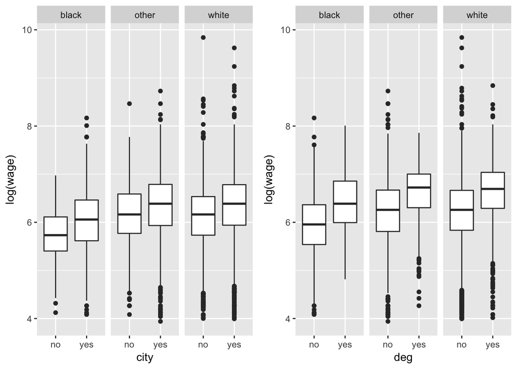

```r
# City (city) by Race (race)
plot5 <- ggplot(data, aes(x = city, y = log(wage))) +
  geom_boxplot() +
  facet_wrap(~race, nrow = 1)

# Degree (deg) by Race (race)
plot6<- ggplot(data, aes(x = deg, y = log(wage))) +
  geom_boxplot() +
  facet_wrap(~race, nrow = 1)

grid.arrange(plot5, plot6, nrow=1)
```

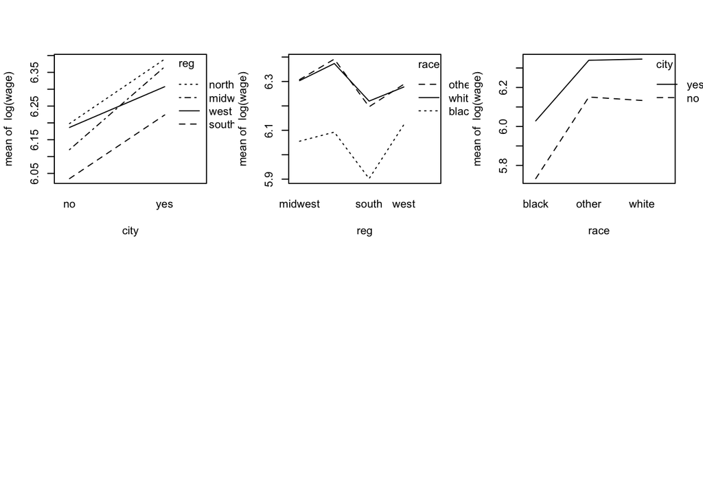

```r
exp <- data$exp
edu <- data$edu
city <- data$city
race <- data$race
reg <- data$reg
emp <- data$emp
wage <- data$wage

par(mfrow=c(2,3))

# City vs. region (yes)
interaction.plot(city,reg,log(wage))

# race vs. region- lines cross (but not significant upon inspection)
interaction.plot(reg, race,log(wage))

# race vs. city- different slopes (slightly significant)
interaction.plot(race, city, log(wage))
```

## II. Statistical Model

```r
# Final model of choice
# log transformation of response, quadratic edu and exp, and interactions added
model <- lm(formula = log(wage) ~ I(edu^2) + exp + I(exp^2) + city + race +
    reg + emp + edu + exp:edu + city:edu + exp:reg + city:reg +
    reg:edu + exp:city + city:race, data = data)
summary(model)
```

```
##
## Call:
## lm(formula = log(wage) ~ I(edu^2) + exp + I(exp^2) + city + race +
##     reg + emp + edu + exp:edu + city:edu + exp:reg + city:reg +
##     reg:edu + exp:city + city:race, data = data)
##
## Residuals:
##     Min      1Q  Median      3Q     Max
## -2.8101 -0.2900  0.0309  0.3294  3.7928
##
## Coefficients:
##                        Estimate Std. Error t value Pr(>|t|)
## (Intercept)           3.802e+00  1.002e-01  37.932  < 2e-16 ***
## I(edu^2)              2.432e-04  2.897e-04   0.839 0.401247
## exp                   8.559e-02  2.318e-03  36.923  < 2e-16 ***
## I(exp^2)             -1.032e-03  2.423e-05 -42.584  < 2e-16 ***
## cityyes              -3.882e-02  5.982e-02  -0.649 0.516375
## raceother             3.132e-01  3.651e-02   8.578  < 2e-16 ***
## racewhite             3.113e-01  3.352e-02   9.286  < 2e-16 ***
## regnortheast          1.015e-01  6.549e-02   1.550 0.121158
## regsouth             -1.292e-01  5.809e-02  -2.225 0.026103 *
## regwest              -7.534e-02  6.211e-02  -1.213 0.225182
## emp                   4.040e-04  4.900e-05   8.246  < 2e-16 ***
## edu                   9.664e-02  1.005e-02   9.613  < 2e-16 ***
## exp:edu              -1.778e-03  1.183e-04 -15.030  < 2e-16 ***
## cityyes:edu           2.252e-02  3.213e-03   7.011 2.44e-12 ***
## exp:regnortheast     -3.837e-03  8.813e-04  -4.353 1.35e-05 ***
## exp:regsouth         -2.432e-03  8.259e-04  -2.945 0.003236 **
## exp:regwest          -1.258e-03  9.178e-04  -1.370 0.170549
## cityyes:regnortheast -4.901e-02  2.667e-02  -1.838 0.066135 .
## cityyes:regsouth     -1.201e-01  2.216e-02  -5.421 6.01e-08 ***
## cityyes:regwest      -9.511e-02  2.388e-02  -3.983 6.82e-05 ***
## regnortheast:edu      3.150e-03  4.178e-03   0.754 0.450941
## regsouth:edu          1.443e-02  3.831e-03   3.767 0.000166 ***
## regwest:edu           1.188e-02  4.022e-03   2.954 0.003141 **
## exp:cityyes           3.055e-03  7.001e-04   4.364 1.29e-05 ***
## cityyes:raceother    -8.300e-02  4.049e-02  -2.050 0.040394 *
## cityyes:racewhite    -7.791e-02  3.683e-02  -2.115 0.034425 *
## ---
## Signif. codes:  0 '***' 0.001 '**' 0.01 '*' 0.05 '.' 0.1 ' ' 1
##
## Residual standard error: 0.5106 on 19832 degrees of freedom
## Multiple R-squared:  0.3545, Adjusted R-squared:  0.3537
## F-statistic: 435.6 on 25 and 19832 DF,  p-value: < 2.2e-16
```

```r
summary(model)$r.squared
```

```
## [1] 0.3544812
```

```r
summary(model)$adj.r.squared
```

```
## [1] 0.3536674
```

```r
extractAIC(model)
```

```
## [1]     26.00 -26669.88
```

## III. Research Question

### Interaction

Before we do our testing, it is important to note that city predictor interacts with race. However, the interaction is not overwhelmingly significant; the p-values are near 0.05

```r
summary(lm(log(wage)~race*city))
```

```
##
## Call:
## lm(formula = log(wage) ~ race * city)
##
## Residuals:
##     Min      1Q  Median      3Q     Max
## -2.3992 -0.4057  0.0406  0.4326  3.7070
##
## Coefficients:
##                   Estimate Std. Error t value Pr(>|t|)
## (Intercept)        5.73235    0.03782 151.553  < 2e-16 ***
## raceother          0.41868    0.04288   9.764  < 2e-16 ***
## racewhite          0.40101    0.03912  10.250  < 2e-16 ***
## cityyes            0.29640    0.04162   7.121 1.11e-12 ***
## raceother:cityyes -0.10785    0.04781  -2.256   0.0241 *
## racewhite:cityyes -0.08424    0.04323  -1.949   0.0513 .
## ---
## Signif. codes:  0 '***' 0.001 '**' 0.01 '*' 0.05 '.' 0.1 ' ' 1
##
## Residual standard error: 0.6227 on 19852 degrees of freedom
## Multiple R-squared:  0.03907,    Adjusted R-squared:  0.03883
## F-statistic: 161.4 on 5 and 19852 DF,  p-value: < 2.2e-16
```

Indeed, you can see from the EDA and interaction graphs that there is wage difference for different racial groups living in cities versus not.

### Research Question 1

$H_0 : \beta_{white}=0, \space \space H_A : \beta_{white} \neq 0$

$t_{calc} = 9.286, \space \space p-value < 2e-16 < 0.05$ We reject the null hypothesis. White has significant slope and differs from black.

### Research Question 2

$H_0 : \beta_{other}=0, \space \space H_A : \beta_{other} \neq 0$

$t_{calc} = 8.578, \space \space p-value < 2e-16 < 0.050$

We reject the null hypothesis. Other racial group has significant slope and differs from black.

$H_0 : \beta_{other}= \beta_{white}, \space \space H_A : \beta_{other} \neq \beta_{white}$

```r
# Manually defining the predictors in the final model to manipulate it for testing
city <- I(data$city=="yes")
white <- I(data$race=="white")
other <- I(data$race=="other")
northeast <- I(data$reg=="northeast")
south <- I(data$reg=="south")
west <- I(data$reg=="west")

lwage <- I(log(data$wage))
lineaeexp <- poly(data$exp,2)[,1]
exp <- I(data$exp) # same as above
quadexp <- poly(data$exp,2)[,2]
lineaeedu <- poly(data$edu,2)[,1]
edu <- I(data$edu) #same as above
quadedu <- poly(data$edu,2)[,2]

emp <- I(data$emp)
exp.edu <- I(exp*edu)
cityyes.edu <- I(city*edu)
exp.south <- I(exp*south)
exp.northeast <- I(exp*northeast)
exp.west <- I(exp*west)

cityyes.south <- I(city*south)
cityyes.west <- I(city*west)
cityyes.northeast <- I(city*northeast)

south.edu <- I(south*edu)
northeast.edu <- I(northeast*edu)
west.edu <- I(west*edu)

exp.cityyes <- I(exp*city)
white.cityyes <- I(city*white)
other.cityyes <- I(city*other)

#same as the original final model- just manually inputted predictor
#full model
model.manual <- lm(lwage~lineaeexp +quadexp +lineaeedu +quadedu  +city +other +white +
northeast +south +west +emp +exp.edu +cityyes.edu +exp.south +exp.northeast +exp.west +
cityyes.south +cityyes.west +cityyes.northeast +south.edu +northeast.edu +west.edu +
exp.cityyes +white.cityyes +other.cityyes)

#reduced model (notice I(other+white))
reduced.model <- lm(lwage~lineaeexp +quadexp +lineaeedu +quadedu  +city +I(other+white) +
northeast +south +west +emp +exp.edu +cityyes.edu +exp.south +exp.northeast +exp.west +
cityyes.south +cityyes.west +cityyes.northeast +south.edu +northeast.edu +west.edu +exp.cityyes +
white.cityyes +other.cityyes)

anova(model.manual, reduced.model)
```

```
## Analysis of Variance Table
##
## Model 1: lwage ~ lineaeexp + quadexp + lineaeedu + quadedu + city + other +
##     white + northeast + south + west + emp + exp.edu + cityyes.edu +
##     exp.south + exp.northeast + exp.west + cityyes.south + cityyes.west +
##     cityyes.northeast + south.edu + northeast.edu + west.edu +
##     exp.cityyes + white.cityyes + other.cityyes
## Model 2: lwage ~ lineaeexp + quadexp + lineaeedu + quadedu + city + I(other +
##     white) + northeast + south + west + emp + exp.edu + cityyes.edu +
##     exp.south + exp.northeast + exp.west + cityyes.south + cityyes.west +
##     cityyes.northeast + south.edu + northeast.edu + west.edu +
##     exp.cityyes + white.cityyes + other.cityyes
##   Res.Df    RSS Df  Sum of Sq      F Pr(>F)
## 1  19832 5170.4
## 2  19833 5170.4 -1 -0.0026705 0.0102 0.9194
```

$f_{calc} = 0.0102, \space \space p-value = 0.9194 > 0.05$

We fail to reject the null hypothesis; it is plausible to assume that white and other race groups do not differ.

### Discussion & Conclusion

Our testings have shown that both research questions are supported. Blacks have statistically different wages compared to whites. And since it is plausible to assume that there is no difference between wages earned by whites and others, blacks have statistically different wages compared to all other race groupsin, in conjunction with the first research question testing. However, with the interaction in mind, whether there is a significant difference in wage between race group depends on other variable, city, and possibly others that I may have missed in the model.

With this study, we cannot know the reason behind pay discrepancy. It would have been interesting to have data on what types of jobs each data point had and compare the wages of different racial groups within the same job. Obviously, doctors get paid more than janitors; we would learn more comparing the wages of black doctors and white doctors. Then, we would be able to study the wage gap that may exist between racial groups doing similar job. Another interesting follow-up study would be to observe if there is job discrimination, maybe analyzing how the rates of different race groups entering high-paying professions compare.

## IV. Appendix

### a. Model Selection

#### Transformation

The QQ-plot below that shows the untransformed response looks very bad (barely aligns with the 45 degree line). The model’s QQ-plot shows that a log transformation of the response is a good choice.

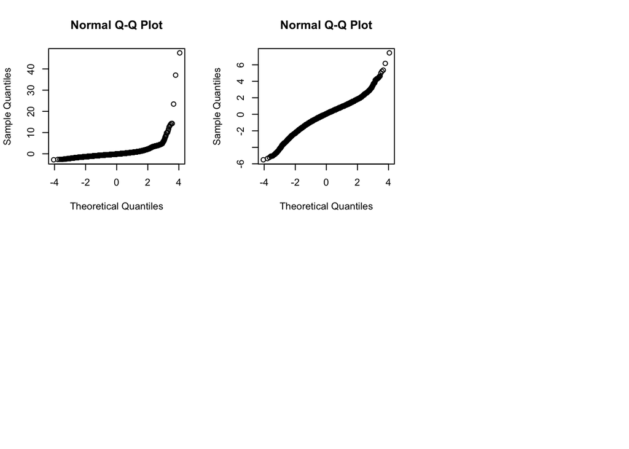

```r
par(mfrow=c(2,3))
qqnorm(rstudent(lm(wage~edu+exp+city+reg+race+deg+com+emp, data=data)))
qqnorm(rstudent(model))
```

#### Functional Forms

According to EDA, experience and education seem to have quadratic forms. Thus, both predictor variables had second-order terms included in the final model.

#### Other Model Candidates

```r
# Candidate 1: basic model
summary(lm(wage~edu+exp+city+reg+race+deg+emp+com,data=train.data))$adj.r.squared
```

```
## [1] 0.2145822
```

```r
extractAIC(lm(wage~edu+exp+city+reg+race+deg+emp+com,data=train.data))
```

```
## [1]     12.0 238411.6
```

```r
# Candidate 2: log transformation of response
summary(lm(log(wage)~edu+exp+city+reg+race+deg+emp+com,data=train.data))$adj.r.squared
```

```
## [1] 0.2894996
```

```r
extractAIC(lm(log(wage)~edu+exp+city+reg+race+deg+emp+com,data=train.data))
```

```
## [1]     12.0 -24804.2
```

```r
# Candidate 3: polynomials for edu and exp added
summary(lm(log(wage)~edu+I(edu^2)+exp+I(exp^2)+city+reg+race+deg+emp,data=train.data))$adj.r.squared
```

```
## [1] 0.3420775
```

```r
extractAIC(lm(log(wage)~edu+I(edu^2)+exp+I(exp^2)+
                city+reg+race+deg+emp,data=train.data))
```

```
## [1]     13.00 -26329.93
```

In the end, my final model has the highest unadjusted (0.3544812) and adjusted R-squared (0.3536674) and the lowest AIC (-26669.88) compared to the above three.

#### Unselected/Selected Variables Based on EDA and Intuition

The basic model where all predictors were used didn’t do very well. The commute distance did not seem to have an effect the response, according to EDA. The college degree information is in a way included in the edu data, so I took it out to avoid overcrowding.

Education level is a well-supported predictor for wage. The number of employees serves as a proxy for company size. Usually, large corporations pay more, so it would be reasonable to include it in the model. The EDA plot of log(wage) vs. emp indeed shows a slight upward linear trend for all racial groups.

#### Interactions

I originally looked at various interaction plots to decide which interaction terms to include. Then I got curious and wrote a small Python script to generate all subsets of the 8 predictor variables, then ran a stepwise regression on it to come up with the final model. I got rid of interactions that were more than two-way, since they only boosted the adjusted R-squared by a little bit and are not very interpretable. I also looked at the summary output and got rid of interactions that were not significant (p < 0.05).

### b. Diagnostics and Model Validation

```r
# Define test data frame for test data
city.test <- I(test.data$city=="yes")
white.test <- I(test.data$race=="white")
other.test <- I(test.data$race=="other")
northeast.test <- I(test.data$reg=="northeast")
south.test <- I(test.data$reg=="south")
west.test <- I(test.data$reg=="west")

lwage.test <- I(log(test.data$wage))
lineaeexp.test <- poly(test.data$exp,2)[,1]
quadexp.test <- poly(test.data$exp,2)[,2]
lineaeedu.test <- poly(test.data$edu,2)[,1]
quadedu.test <- poly(test.data$edu,2)[,2]
emp.test <- I(test.data$emp)

exp.edu.test <- I(lineaeexp.test*lineaeedu.test)
cityyes.edu.test <- I(city.test*lineaeedu.test)
exp.south.test <- I(lineaeexp.test*south.test)
exp.northeast.test <- I(lineaeexp.test*northeast.test)
exp.west.test <- I(lineaeexp.test*west.test)

cityyes.south.test <- I(city.test*south.test)
cityyes.west.test <- I(city.test*west.test)
cityyes.northeast.test <- I(city.test*northeast.test)

south.edu.test <- I(south.test*lineaeedu.test)
northeast.edu.test <- I(northeast.test*lineaeedu.test)
west.edu.test <- I(west.test*lineaeedu.test)

exp.cityyes.test <- I(lineaeexp.test*city.test)
white.cityyes.test <- I(city.test*white.test)
other.cityyes.test <- I(city.test*other.test)


X.test <- data.frame(city = city.test, white = white.test, other= other.test, northeast= northeast.test, south = south.test, west= west.test, lineaeexp= lineaeexp.test, quadexp= quadexp.test, lineaeedu= lineaeedu.test, quadedu= quadedu.test, emp= emp.test, exp.edu = exp.edu.test, cityyes.edu= cityyes.edu.test, exp.south= exp.south.test, exp.northeast= exp.northeast.test, exp.west= exp.west.test, cityyes.south= cityyes.south.test, cityyes.west= cityyes.west.test, cityyes.northeast= cityyes.northeast.test, south.edu= south.edu.test, northeast.edu = northeast.edu.test, west.edu = west.edu.test, exp.cityyes= exp.cityyes.test, white.cityyes= white.cityyes.test, other.cityyes= other.cityyes.test)

y.hat.mspr <- predict(model.manual,newdata = X.test)

# Compute MSPR
n.star <- nrow(test.data)
MSPR <- 1/n.star*sum((lwage.test-y.hat.mspr)^2)
MSE <- (summary(lm(model.manual))$sigma)^2

# Compare MSPR  to MSE
MSPR
```

```
## [1] 0.9125337
```

```r
MSE
```

```
## [1] 0.2607123
```

```r
MSPR/MSE
```

```
## [1] 3.500156
```

### c. Influential Observations and Collinearity

DFBETAS would be more appropriate here since we are focusing on answering the research questions (testing slopes), not predicting.

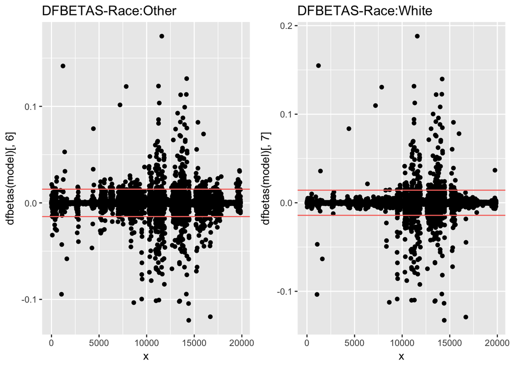

```r
n <- nrow(data)
x <- seq(1, nrow(data))
y.intc <- 2/sqrt(n)

dfplot1 <-ggplot(data, aes(x =x, y = dfbetas(model)[,6])) +
  geom_point() +
  geom_hline(aes(yintercept = y.intc, col= "red")) +
  geom_hline(aes(yintercept = -y.intc, col = "red"))+
  theme(legend.position="none") + labs(title="DFBETAS-Race:Other")

dfplot2 <-ggplot(data, aes(x =x, y = dfbetas(model)[,7])) +
  geom_point() +
  geom_hline(aes(yintercept = y.intc, col= "red")) +
  geom_hline(aes(yintercept = -y.intc, col = "red"))+
  theme(legend.position="none")+labs(title="DFBETAS-Race:White")

grid.arrange(dfplot1,dfplot2, nrow=1)
```

As expected from the size of the given data set, there are many influential observations. It may be wise to come up with a different model.

```r
mean(vif(model)[,3])
```

```
## [1] 4.512196
```

```r
numeric_preds <- data.frame(lwage=lwage, edu=edu, exp=exp, edu.sq = quadedu, exp.sq = quadexp, exp.edu = exp.edu,  emp=emp)
cor(numeric_preds)
```

```
##               lwage           edu           exp       edu.sq        exp.sq
## lwage    1.00000000  3.697235e-01  2.327511e-01 9.107858e-02 -2.920242e-01
## edu      0.36972348  1.000000e+00 -2.793636e-01 1.162456e-14 -1.530700e-01
## exp      0.23275115 -2.793636e-01  1.000000e+00 1.417241e-01  5.205299e-16
## edu.sq   0.09107858  1.162456e-14  1.417241e-01 1.000000e+00  7.041300e-02
## exp.sq  -0.29202423 -1.530700e-01  5.205299e-16 7.041300e-02  1.000000e+00
## exp.edu  0.39153460  1.545783e-01  8.733689e-01 1.863268e-02 -1.709391e-01
## emp      0.05989805  2.034405e-02 -3.872245e-03 8.796929e-03 -1.777381e-02
##              exp.edu          emp
## lwage    0.391534596  0.059898053
## edu      0.154578334  0.020344053
## exp      0.873368935 -0.003872245
## edu.sq   0.018632680  0.008796929
## exp.sq  -0.170939091 -0.017773812
## exp.edu  1.000000000  0.007463414
## emp      0.007463414  1.000000000
```

## d. Other Ideas on Model Selection

```r
summary(lm(formula = log(wage) ~ I(edu^2) + exp + I(exp^2) + city + race +
  emp + reg + deg + edu + city:reg + exp:city + exp:reg + exp:emp +
  city:deg + exp:deg + race:emp + race:deg + reg:deg + city:edu +
  exp:edu + reg:edu + exp:race + race:edu + emp:edu + exp:city:edu +
  city:reg:edu + race:emp:edu + exp:race:edu, data = data))$adj.r.squared
```

```
## [1] 0.3540196
```

A way to increase adjusted R-squared would be to brute forc2e it, where you try every possible combination of interactions and higher order terms and keep your computer running forever until you reach a target value (say, 50%). It would be interesting to see what model you would get, but I assume it won’t be very interpretable.